# An anti-inflammatory response of an organic food intervention treatment by reducing pesticide exposures in children of Cyprus: a cluster-randomized crossover trial - Sensitivity analysis Part 2

# Sensitivity analysis Part 2

This script includes the sensitivity analysis (Part 2), in which samples from participants who reported medication use and/or illness within two days before sampling were excluded. The output of the Part 2 script needs to be created (produced_data/lmmdata_dates_MOD).

## Models details

All models were adjusted for the baseline value of the outcome.

All models were adjusted for the creatinine levels using two ways:

- CRP and pesticides measurements were divided with the respective creatinine measurements
- Creatinine was included as a fixed effect

Initial model (model for objective 1):

- Random part: participants
- Fixed effect: treatment condition (organic or conventional) and time (days of treatment, where time=0 was the start of the treatment)
- Interaction term: time*phase
- Check interaction term:
- if p-value>0.05 remove from the model

### Log creatinine adjusted CRP ~ baseline log creatinine adjusted CRP + DaysfromTreatment + phase + (phase*DaysfromTreatment if p<0.05) + random(…)

**Initial model (including the interaction term)**

logadj_crp_S_BL + DaysfromTreatment + phase + DaysfromTreatment * phase + (1 | ID)

|  | logadj crp S TR |  |  |
| --- | --- | --- | --- |
| Predictors | Estimates | CI | p |
| (Intercept) | -0.264 | -0.510 – -0.018 | **0.035** |
| logadj crp S BL | 0.038 | -0.038 – 0.114 | 0.327 |
| DaysfromTreatment | 0.012 | 0.003 – 0.021 | **0.010** |
| phase [Organic] | 0.277 | -0.034 – 0.588 | 0.081 |
| DaysfromTreatment × phase [Organic] | -0.018 | -0.030 – -0.006 | **0.004** |
| Random Effects |  |  |  |
| σ<sup>2</sup> | 0.71 |  |  |
| τ<sub>00</sub> <sub>ID</sub> | 0.15 |  |  |
| ICC | 0.18 |  |  |
| N <sub>ID</sub> | 147 |  |  |
| Observations | 658 |  |  |
| Marginal R<sup>2</sup> / Conditional R<sup>2</sup> | 0.018 / 0.193 |  |  |

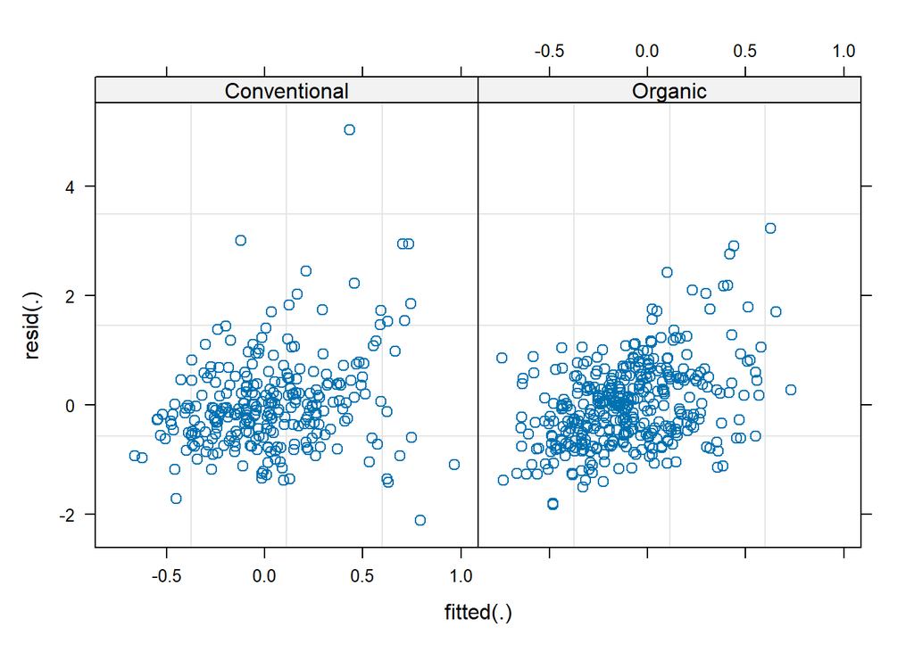

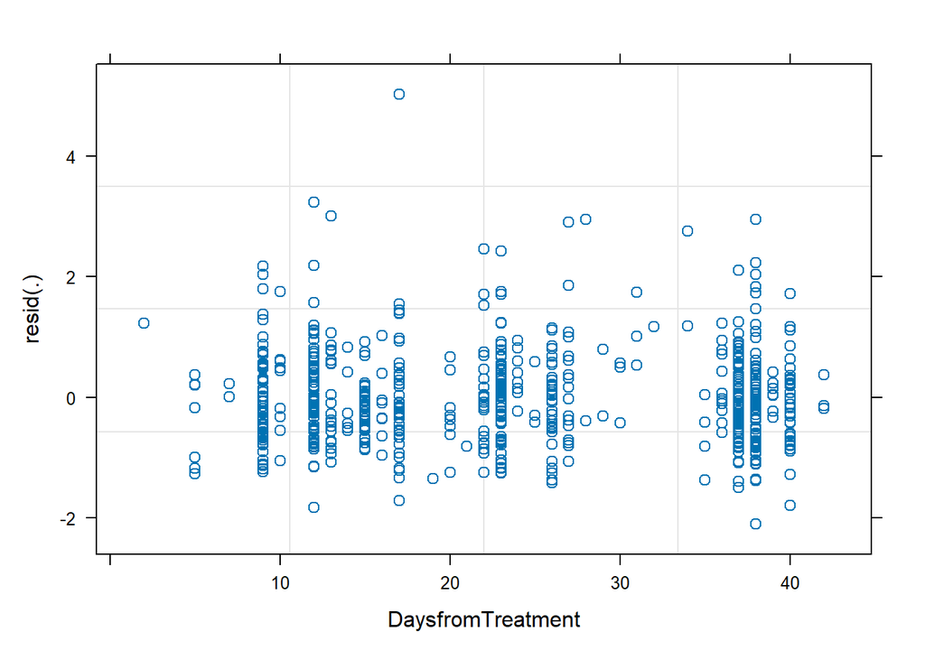

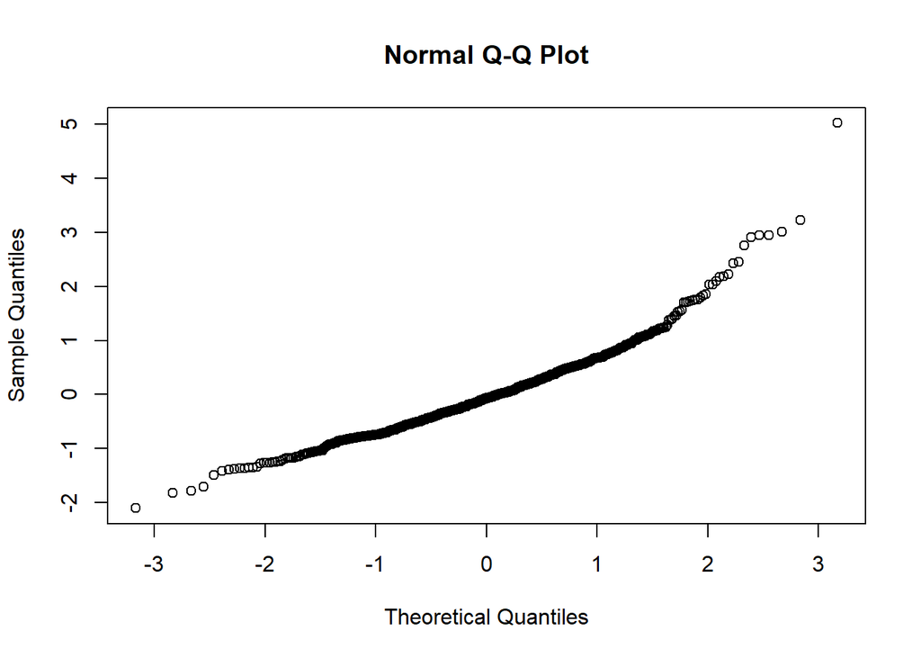

### Log CRP ~ baseline Log CRP + DaysfromTreatment + phase + creatinine_S + (phase*DaysfromTreatment if p<0.05) + random(…)

logcrp_S_BL + DaysfromTreatment + phase + creatinine_S + (1 | ID)

|  | logcrp S TR |  |  |
| --- | --- | --- | --- |
| Predictors | Estimates | CI | p |
| (Intercept) | -0.000 | -0.179 – 0.179 | 0.999 |
| logcrp S BL | 0.023 | -0.043 – 0.089 | 0.491 |
| DaysfromTreatment | 0.001 | -0.005 – 0.007 | 0.840 |
| phase [Organic] | -0.115 | -0.249 – 0.020 | 0.095 |
| creatinine S | 0.064 | -0.009 – 0.136 | 0.088 |
| Random Effects |  |  |  |
| σ<sup>2</sup> | 0.74 |  |  |
| τ<sub>00</sub> <sub>ID</sub> | 0.09 |  |  |
| ICC | 0.11 |  |  |
| N <sub>ID</sub> | 147 |  |  |
| Observations | 658 |  |  |
| Marginal R<sup>2</sup> / Conditional R<sup>2</sup> | 0.010 / 0.119 |  |  |

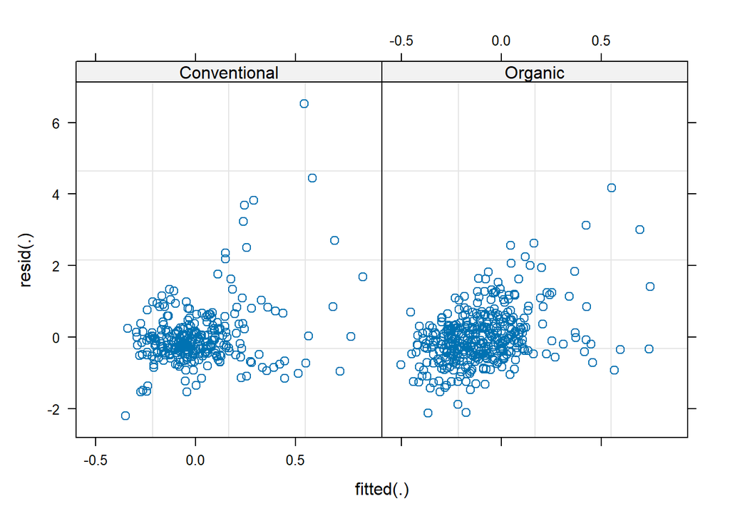

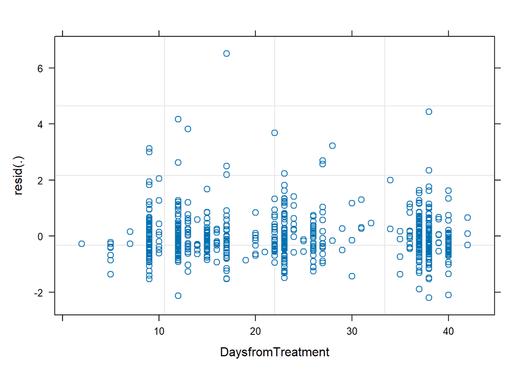

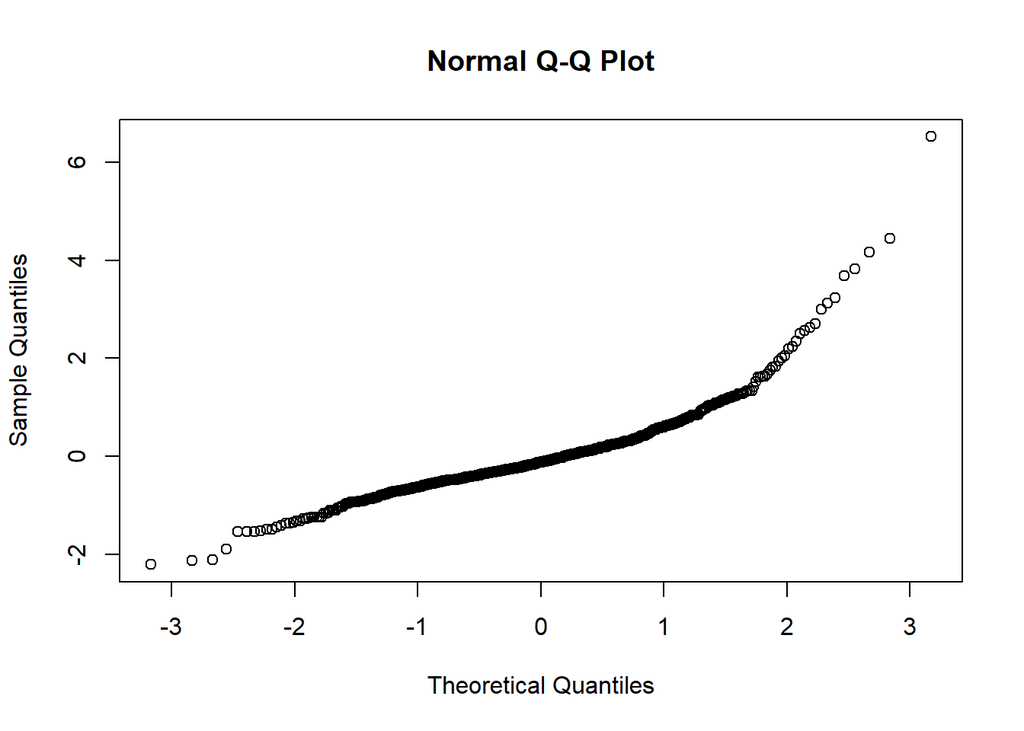

### Merge the models of objective 1

Merge the models of objective 1

|  | logadj crp S TR |  |  | logcrp S TR |  |  |
| --- | --- | --- | --- | --- | --- | --- |
| Predictors | Estimates | CI | p | Estimates | CI | p |
| (Intercept) | -0.264 | -0.510 – -0.018 | **0.035** | -0.000 | -0.179 – 0.179 | 0.999 |
| logadj crp S BL | 0.038 | -0.038 – 0.114 | 0.327 |  |  |  |
| DaysfromTreatment | 0.012 | 0.003 – 0.021 | **0.010** | 0.001 | -0.005 – 0.007 | 0.840 |
| phase [Organic] | 0.277 | -0.034 – 0.588 | 0.081 | -0.115 | -0.249 – 0.020 | 0.095 |
| DaysfromTreatment × phase [Organic] | -0.018 | -0.030 – -0.006 | **0.004** |  |  |  |
| logcrp S BL |  |  |  | 0.023 | -0.043 – 0.089 | 0.491 |
| creatinine S |  |  |  | 0.064 | -0.009 – 0.136 | 0.088 |
| Random Effects |  |  |  |  |  |  |
| σ<sup>2</sup> | 0.71 |  |  | 0.74 |  |  |
| τ<sub>00</sub> | 0.15 <sub>ID</sub> |  |  | 0.09 <sub>ID</sub> |  |  |
| ICC | 0.18 |  |  | 0.11 |  |  |
| N | 147 <sub>ID</sub> |  |  | 147 <sub>ID</sub> |  |  |
| Observations | 658 |  |  | 658 |  |  |
| Marginal R<sup>2</sup> / Conditional R<sup>2</sup> | 0.018 / 0.193 |  |  | 0.010 / 0.119 |  |  |

### Models for objective 2

A second model was made to assess the association between biomarker of exposure to pesticides (3-PBA and 6-CN, separately) and biomarker of inflammation (CRP).

- Random part: participants
- Fixed effect: each biomarker of exposure to pesticides, time (days of treatment, where time=0 was the start of the treatment), age and sex

### Log creatinine adjusted CRP ~ Log creatinine adjusted baseline CRP + 6-CN (binary) + DaysfromTreatment + sex + baseline age + random(…)

logadj_crp_S_BL + cnlod + DaysfromTreatment + Sex + age_baseline_S + (1 | ID)

|  | logadj crp S TR |  |  |
| --- | --- | --- | --- |
| Predictors | Estimates | CI | p |
| (Intercept) | -0.121 | -0.314 – 0.073 | 0.221 |
| logadj crp S BL | 0.032 | -0.046 – 0.109 | 0.426 |
| cnlod [Above LOD] | 0.029 | -0.128 – 0.187 | 0.716 |
| DaysfromTreatment | 0.001 | -0.004 – 0.007 | 0.626 |
| Sex [Female] | 0.043 | -0.141 – 0.227 | 0.647 |
| age baseline S | -0.024 | -0.116 – 0.068 | 0.607 |
| Random Effects |  |  |  |
| σ<sup>2</sup> | 0.73 |  |  |
| τ<sub>00</sub> <sub>ID</sub> | 0.15 |  |  |
| ICC | 0.17 |  |  |
| N <sub>ID</sub> | 146 |  |  |
| Observations | 657 |  |  |
| Marginal R<sup>2</sup> / Conditional R<sup>2</sup> | 0.004 / 0.175 |  |  |

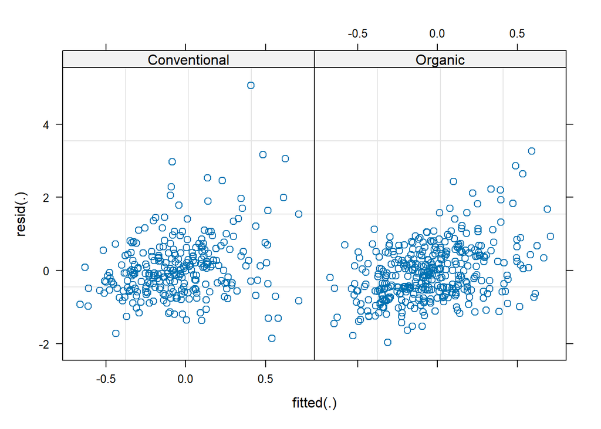

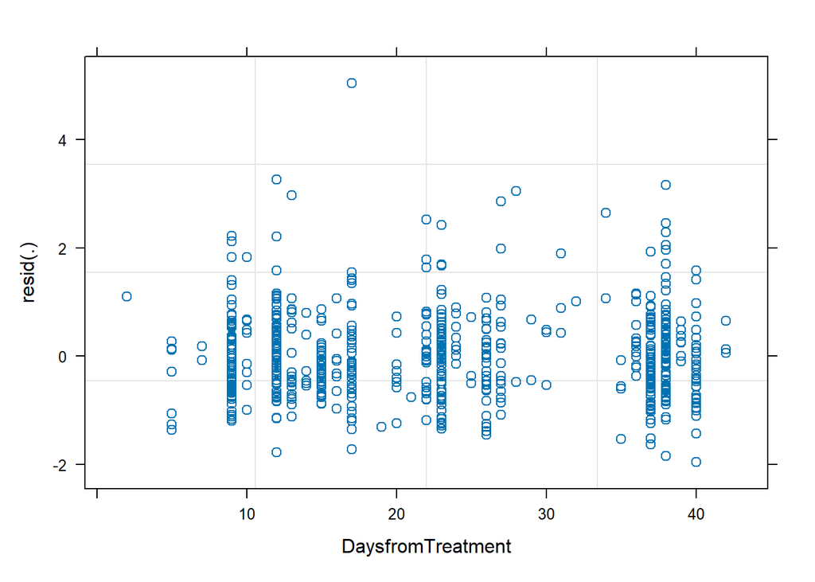

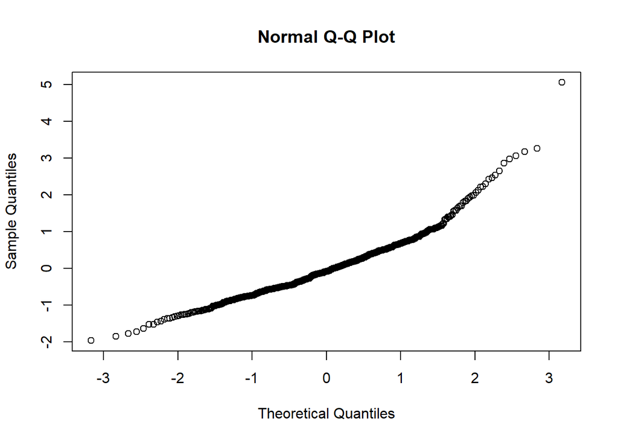

### Log CRP ~ log baseline CRP + 6-CN + DaysfromTreatment + sex + baseline age + creatinine_s + random(…)

logcrp_S_BL + cnlod + DaysfromTreatment + Sex + age_baseline_S + creatinine_S + (1 | ID)

|  | logcrp S TR |  |  |
| --- | --- | --- | --- |
| Predictors | Estimates | CI | p |
| (Intercept) | -0.047 | -0.235 – 0.141 | 0.621 |
| logcrp S BL | 0.020 | -0.047 – 0.088 | 0.558 |
| cnlod [Above LOD] | 0.025 | -0.132 – 0.182 | 0.754 |
| DaysfromTreatment | 0.000 | -0.005 – 0.006 | 0.871 |
| Sex [Female] | -0.047 | -0.215 – 0.120 | 0.580 |
| age baseline S | -0.017 | -0.102 – 0.067 | 0.686 |
| creatinine S | 0.059 | -0.014 – 0.133 | 0.113 |
| Random Effects |  |  |  |
| σ<sup>2</sup> | 0.75 |  |  |
| τ<sub>00</sub> <sub>ID</sub> | 0.09 |  |  |
| ICC | 0.11 |  |  |
| N <sub>ID</sub> | 146 |  |  |
| Observations | 657 |  |  |
| Marginal R<sup>2</sup> / Conditional R<sup>2</sup> | 0.007 / 0.118 |  |  |

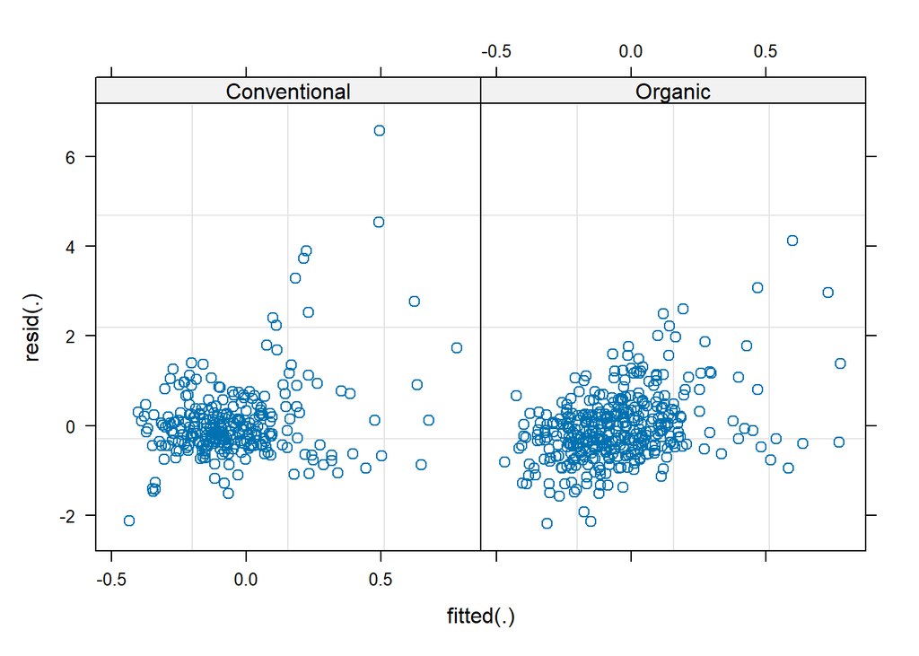

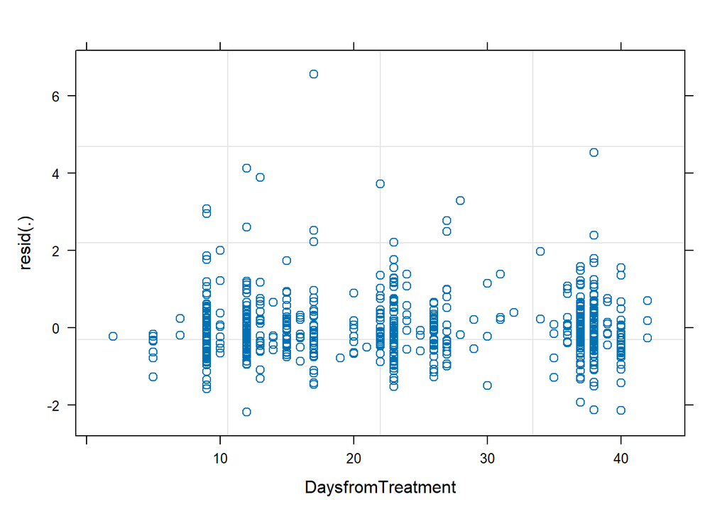

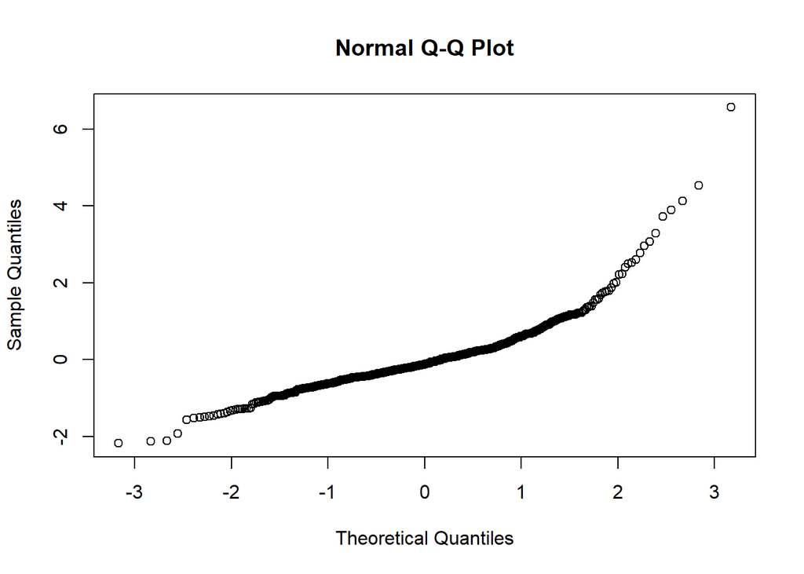

### Merge the models of objective 2-6-CN

Merge the models of objective 2-6-CN

|  | logadj crp S TR |  |  | logcrp S TR |  |  |
| --- | --- | --- | --- | --- | --- | --- |
| Predictors | Estimates | CI | p | Estimates | CI | p |
| (Intercept) | -0.121 | -0.314 – 0.073 | 0.221 | -0.047 | -0.235 – 0.141 | 0.621 |
| logadj crp S BL | 0.032 | -0.046 – 0.109 | 0.426 |  |  |  |
| cnlod [Above LOD] | 0.029 | -0.128 – 0.187 | 0.716 | 0.025 | -0.132 – 0.182 | 0.754 |
| DaysfromTreatment | 0.001 | -0.004 – 0.007 | 0.626 | 0.000 | -0.005 – 0.006 | 0.871 |
| Sex [Female] | 0.043 | -0.141 – 0.227 | 0.647 | -0.047 | -0.215 – 0.120 | 0.580 |
| age baseline S | -0.024 | -0.116 – 0.068 | 0.607 | -0.017 | -0.102 – 0.067 | 0.686 |
| logcrp S BL |  |  |  | 0.020 | -0.047 – 0.088 | 0.558 |
| creatinine S |  |  |  | 0.059 | -0.014 – 0.133 | 0.113 |
| Random Effects |  |  |  |  |  |  |
| σ<sup>2</sup> | 0.73 |  |  | 0.75 |  |  |
| τ<sub>00</sub> | 0.15 <sub>ID</sub> |  |  | 0.09 <sub>ID</sub> |  |  |
| ICC | 0.17 |  |  | 0.11 |  |  |
| N | 146 <sub>ID</sub> |  |  | 146 <sub>ID</sub> |  |  |
| Observations | 657 |  |  | 657 |  |  |
| Marginal R<sup>2</sup> / Conditional R<sup>2</sup> | 0.004 / 0.175 |  |  | 0.007 / 0.118 |  |  |

### Log creatinine adjusted CRP ~ Log creatinine adjusted baseline CRP + creatinine adjusted 3-PBA + DaysfromTreatment + sex + baseline age + random(…)

logadj_crp_S_BL + adj_pb1000_S + DaysfromTreatment + Sex + age_baseline_S + (1 | ID)

|  | logadj crp S TR |  |  |
| --- | --- | --- | --- |
| Predictors | Estimates | CI | p |
| (Intercept) | -0.082 | -0.270 – 0.105 | 0.388 |
| logadj crp S BL | 0.036 | -0.041 – 0.113 | 0.361 |
| adj pb1000 S | 0.105 | 0.036 – 0.175 | **0.003** |
| DaysfromTreatment | 0.000 | -0.006 – 0.006 | 0.901 |
| Sex [Female] | 0.036 | -0.147 – 0.218 | 0.702 |
| age baseline S | -0.023 | -0.115 – 0.068 | 0.617 |
| Random Effects |  |  |  |
| σ<sup>2</sup> | 0.72 |  |  |
| τ<sub>00</sub> <sub>ID</sub> | 0.15 |  |  |
| ICC | 0.17 |  |  |
| N <sub>ID</sub> | 146 |  |  |
| Observations | 657 |  |  |
| Marginal R<sup>2</sup> / Conditional R<sup>2</sup> | 0.016 / 0.184 |  |  |

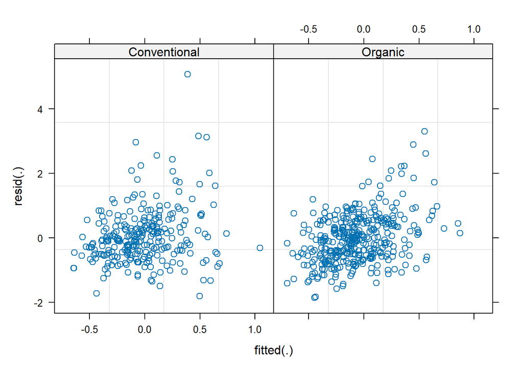

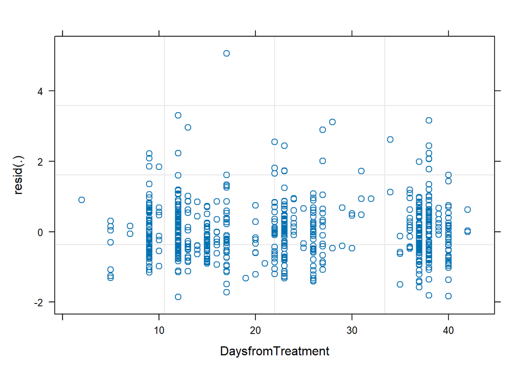

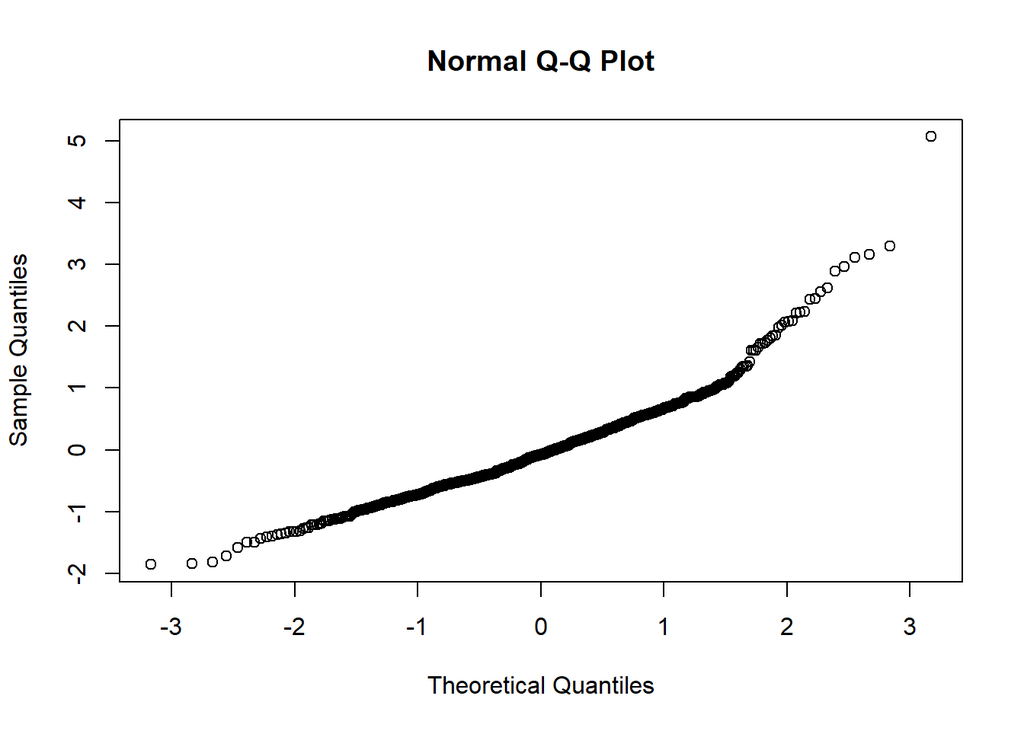

### Log CRP ~ Log baseline CRP + 3-PBA + DaysfromTreatment + sex + baseline age + creatinine_S + random(…)

logcrp_S_BL + pb1000_S + DaysfromTreatment + Sex + age_baseline_S + creatinine_S + (1 | ID)

|  | logcrp S TR |  |  |
| --- | --- | --- | --- |
| Predictors | Estimates | CI | p |
| (Intercept) | -0.042 | -0.225 – 0.141 | 0.650 |
| logcrp S BL | 0.020 | -0.048 – 0.088 | 0.563 |
| pb1000 S | -0.010 | -0.078 – 0.059 | 0.784 |
| DaysfromTreatment | 0.001 | -0.005 – 0.007 | 0.852 |
| Sex [Female] | -0.048 | -0.215 – 0.120 | 0.576 |
| age baseline S | -0.017 | -0.101 – 0.067 | 0.689 |
| creatinine S | 0.059 | -0.014 – 0.133 | 0.113 |
| Random Effects |  |  |  |
| σ<sup>2</sup> | 0.75 |  |  |
| τ<sub>00</sub> <sub>ID</sub> | 0.09 |  |  |
| ICC | 0.11 |  |  |
| N <sub>ID</sub> | 146 |  |  |
| Observations | 657 |  |  |
| Marginal R<sup>2</sup> / Conditional R<sup>2</sup> | 0.007 / 0.118 |  |  |

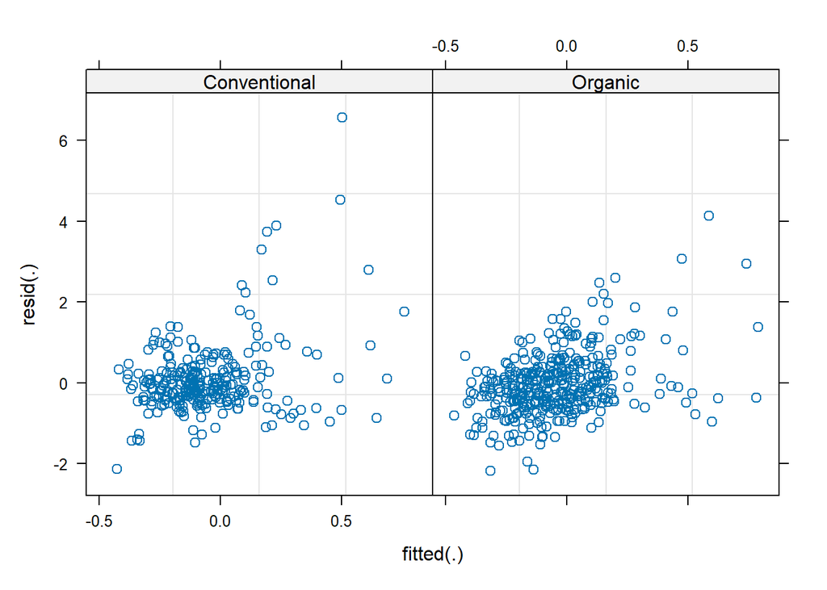

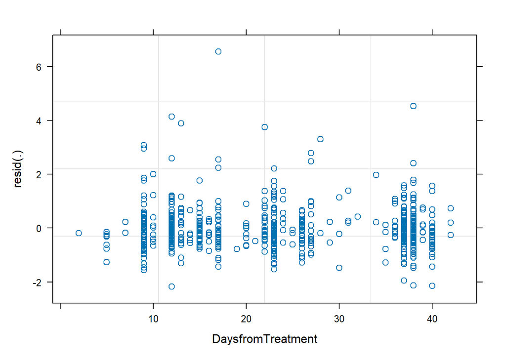

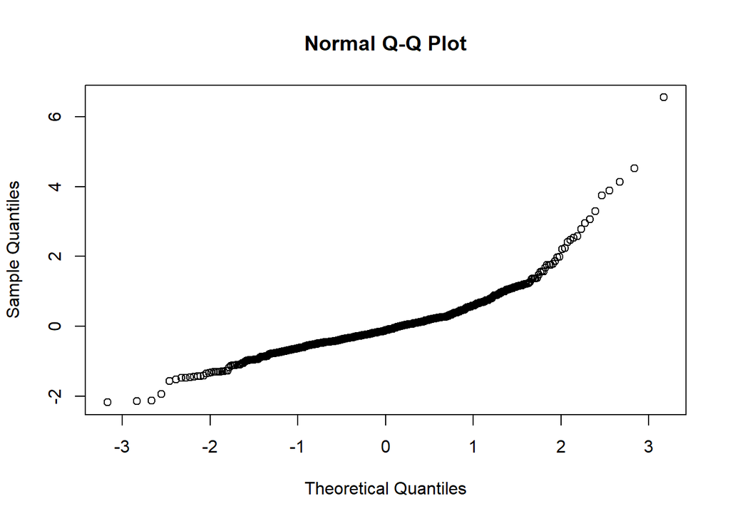

### Merge the models of objective 2-3-PBA

Merge the models of objective 2 3-BPA

|  | logadj crp S TR |  |  | logcrp S TR |  |  |
| --- | --- | --- | --- | --- | --- | --- |
| Predictors | Estimates | CI | p | Estimates | CI | p |
| (Intercept) | -0.082 | -0.270 – 0.105 | 0.388 | -0.042 | -0.225 – 0.141 | 0.650 |
| logadj crp S BL | 0.036 | -0.041 – 0.113 | 0.361 |  |  |  |
| adj pb1000 S | 0.105 | 0.036 – 0.175 | **0.003** |  |  |  |
| DaysfromTreatment | 0.000 | -0.006 – 0.006 | 0.901 | 0.001 | -0.005 – 0.007 | 0.852 |
| Sex [Female] | 0.036 | -0.147 – 0.218 | 0.702 | -0.048 | -0.215 – 0.120 | 0.576 |
| age baseline S | -0.023 | -0.115 – 0.068 | 0.617 | -0.017 | -0.101 – 0.067 | 0.689 |
| logcrp S BL |  |  |  | 0.020 | -0.048 – 0.088 | 0.563 |
| pb1000 S |  |  |  | -0.010 | -0.078 – 0.059 | 0.784 |
| creatinine S |  |  |  | 0.059 | -0.014 – 0.133 | 0.113 |
| Random Effects |  |  |  |  |  |  |
| σ<sup>2</sup> | 0.72 |  |  | 0.75 |  |  |
| τ<sub>00</sub> | 0.15 <sub>ID</sub> |  |  | 0.09 <sub>ID</sub> |  |  |
| ICC | 0.17 |  |  | 0.11 |  |  |
| N | 146 <sub>ID</sub> |  |  | 146 <sub>ID</sub> |  |  |
| Observations | 657 |  |  | 657 |  |  |
| Marginal R<sup>2</sup> / Conditional R<sup>2</sup> | 0.016 / 0.184 |  |  | 0.007 / 0.118 |  |  |

## Benjamini-Hochberg p-value adjustment - without the intercepts

|  | Model | FixedEffects | p | BH_p |
| --- | --- | --- | --- | --- |
| 20 | crpadjusted_3PBA | 3PBA | 0.003 | 0.060 |
| 2 | crpadjusted_INT | Days*Phase | 0.004 | 0.060 |
| 1 | crpadjusted_INT | Time (days) | 0.010 | 0.100 |
| 4 | crpadjusted_INT | Organic diet | 0.081 | 0.424 |
| 5 | crp_nonadjusted_nonINT | creatinine | 0.088 | 0.424 |
| 8 | crp_nonadjusted_nonINT | Organic diet | 0.095 | 0.424 |
| 16 | crp_nonadjusted_6CN | creatinine | 0.113 | 0.424 |
| 26 | crp_nonadjusted_6PBA | creatinine | 0.113 | 0.424 |
| 3 | crpadjusted_INT | Baseline CRP levels | 0.328 | 0.895 |
| 23 | crpadjusted_3PBA | Baseline crp levels | 0.362 | 0.895 |
| 12 | crpadjusted_6CN | Baseline CRP levels | 0.428 | 0.895 |
| 7 | crp_nonadjusted_nonINT | Baseline crp levels (no cr adjusted) | 0.492 | 0.895 |
| 18 | crp_nonadjusted_6CN | Baseline crp levels (no cr adjusted) | 0.559 | 0.895 |
| 28 | crp_nonadjusted_6PBA | logcrp_S_BL | 0.564 | 0.895 |
| 30 | crp_nonadjusted_6PBA | SexFemale | 0.577 | 0.895 |
| 19 | crp_nonadjusted_6CN | SexFemale | 0.580 | 0.895 |
| 9 | crpadjusted_6CN | Age | 0.608 | 0.895 |
| 21 | crpadjusted_3PBA | Age | 0.617 | 0.895 |
| 11 | crpadjusted_6CN | Time (days) | 0.626 | 0.895 |
| 13 | crpadjusted_6CN | SexFemale | 0.647 | 0.895 |
| 14 | crp_nonadjusted_6CN | Age | 0.687 | 0.895 |
| 25 | crp_nonadjusted_6PBA | Age | 0.690 | 0.895 |
| 24 | crpadjusted_3PBA | SexFemale | 0.702 | 0.895 |
| 10 | crpadjusted_6CN | 6-CN (above LOD) | 0.716 | 0.895 |
| 15 | crp_nonadjusted_6CN | 6CN (above LOD) | 0.754 | 0.901 |
| 29 | crp_nonadjusted_6PBA | 3-PBA | 0.784 | 0.901 |
| 6 | crp_nonadjusted_nonINT | Time (days) | 0.840 | 0.901 |
| 27 | crp_nonadjusted_6PBA | Time (days) | 0.852 | 0.901 |
| 17 | crp_nonadjusted_6CN | Time (days) | 0.871 | 0.901 |
| 22 | crpadjusted_3PBA | Time (days) | 0.901 | 0.901 |